# Predicting Sale Prices of Homes in Ames, Iowa

Kirstin Pruitt, Mahsa Sheikhihafshejani, Larry Yu

## Business Understanding

### Overview of Dataset

The dataset chosen for Lab One is the Ames housing dataset gathered and contributed by Dean De Cock of Truman State University and made widely available by Kaggle [1]. The purpose of the dataset is to predict the final sale price of individual homes in Ames, Iowa, based on various characteristics described by the 79 explanatory variables. This detailed collection of home features was gathered to highlight that there is much more to the real estate scene than what meets the eye. It proves that the price of a house is the product of a culmination of factors such as railroad proximity and slope of a property, rather than simply asking the run-of-the-mill questions like how many bedrooms does it have or is there a “white picket fence”? The dataset contains training and testing data, which consist of 1460 and 1459 observations, respectively. Of the aforementioned 79 explanatory variables, 46 are categorical (23 nominal and 23 ordinal) and 33 are numeric (14 discrete and 19 continuous).

The 46 categorical variables involved in the datasets contain a considerable range of classes under which the houses in the study fall. The nominal variables, which have no respective underlying ranking system, include information about the house that describe such things as dwelling, location, style, materials, heating and electrical systems, and garages. On the other hand, the ordinal variables rate numerous features and characteristics of the property involved in the sale.

The 14 discrete variables were incorporated to evaluate specific numbers of features in the home such as number of bedrooms, bathrooms (full and half), and kitchens on the basement level and above ground. Number of cars that could fit in the garage and year it was built, number of fireplaces, and information about dates of construction, remodeling, and sales were also encompassed by these discrete variables.

The 19 continuous variables consist mostly of square footage of different spaces within the home. In some instances, those spaces are broken down into separate variables based on the finish of the space, occurring, for instance, with basements and porches, which have four and five respective categories. Still other variables that are commonly expected in the real estate scene are included such as lot size in square feet and above ground square footage of living area. The remaining variables in this category that do not contain information about area dimensions are monetary values of miscellaneous features and, of course, Sale Price (in the training set, but not in the test set).

### The Prediction Task

Predicting the sale price of homes is an important task in today’s market. Home buyers want assurance that they’re getting the best deal and not overpaying for a home, while sellers are looking to maximize their profits - a vicious cycle that has become quite monstrous when coupled with inflation rates. The typical home buyer will look at a few features like the basement, the master bathroom, and how many cars fit in the garage. They may not realize that the home is actually within 200 feet of a railroad if the home is strategically shown at times when trains aren’t running. This dataset challenges virtually every feature one could think of for homes in Ames, Iowa to most accurately determine a good sale price and ultimately what the final sale price will be of a home - which may not be the same.

It is important to note that according to the US Census Bureau, the estimated median home value of owner-occupied units (2016-2020) was \$ 213, 500, but the median household income (in 2020 dollars) between 2016 and 2020 was \\$ 50, 783 [2]. From this, it is evident that home buying is a significant undertaking for the majority of occupants of the town. Thus is the essence of the incentive behind our prediction task - protecting people from getting ripped off when spending their hard-earned money.

In order for our prediction model to be rendered useful to the home-buying market of Ames, Iowa, we seek to accurately predict sale prices within a margin of error of 4.21%, which is reflective of the average inflation rate of the housing market between 1967 and 2022 [3]. The thought behind this is home buyers are frequently aware of inflation and are expected to account for this in some way when trying to come up with the money to purchase a home. Utilizing this relatively low percentage as a threshold, the model will need to more accurately predict the sale prices of more affordable housing in the Ames market, while having a bit more of a buffer when it comes to more expensive homes. When considering this approach, it is geared toward the protection of the average home buyer, who, in line with Census Bureau statistics, does not likely have the extra income to afford a drastic undershoot on our end. On the flip side of that, there are not many houses in Ames that go for $ 300, 000 and above. Given that the supply of these homes is fairly low, we expect the demand for them in more affluent parts to drive up the sale prices, so our margin of error accounts for more flexibility on the predicted sale prices of homes whose buyers are more likely to have spare change, if you will. Plot 0 below shows the distribution of sale prices in our dataset.

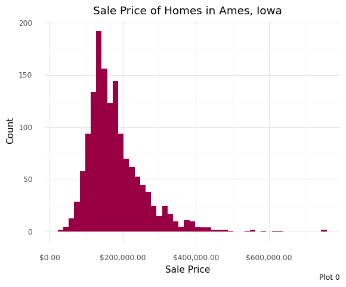

```python
print(sale_price)
```

## Data Understanding

### The Code

```python
import pandas as pd
import numpy as np
```

```python
train = pd.read_csv(r'/Users/kirstinpruitt/Desktop/CS 7324/data/house prices/train.csv')
test = pd.read_csv(r'/Users/kirstinpruitt/Desktop/CS 7324/data/house prices/test.csv')
train.head()
```

|  | Id | MSSubClass | MSZoning | LotFrontage | LotArea | Street | Alley | LotShape | LandContour | Utilities | ... | PoolArea | PoolQC | Fence | MiscFeature | MiscVal | MoSold | YrSold | SaleType | SaleCondition | SalePrice |
| --- | --- | --- | --- | --- | --- | --- | --- | --- | --- | --- | --- | --- | --- | --- | --- | --- | --- | --- | --- | --- | --- |
| 0 | 1 | 60 | RL | 65.0 | 8450 | Pave | NaN | Reg | Lvl | AllPub | ... | 0 | NaN | NaN | NaN | 0 | 2 | 2008 | WD | Normal | 208500 |
| 1 | 2 | 20 | RL | 80.0 | 9600 | Pave | NaN | Reg | Lvl | AllPub | ... | 0 | NaN | NaN | NaN | 0 | 5 | 2007 | WD | Normal | 181500 |
| 2 | 3 | 60 | RL | 68.0 | 11250 | Pave | NaN | IR1 | Lvl | AllPub | ... | 0 | NaN | NaN | NaN | 0 | 9 | 2008 | WD | Normal | 223500 |
| 3 | 4 | 70 | RL | 60.0 | 9550 | Pave | NaN | IR1 | Lvl | AllPub | ... | 0 | NaN | NaN | NaN | 0 | 2 | 2006 | WD | Abnorml | 140000 |
| 4 | 5 | 60 | RL | 84.0 | 14260 | Pave | NaN | IR1 | Lvl | AllPub | ... | 0 | NaN | NaN | NaN | 0 | 12 | 2008 | WD | Normal | 250000 |

5 rows × 81 columns

```python
# assign a variable that indicates which dataset the observation belongs to
# create a SalePrice column in the test set to mirror the columns in the train set
train2 = train.assign(data = "train")
test2 = test.assign(data = "test", SalePrice = np.nan)
```

```python
test2.head()
```

|  | Id | MSSubClass | MSZoning | LotFrontage | LotArea | Street | Alley | LotShape | LandContour | Utilities | ... | PoolQC | Fence | MiscFeature | MiscVal | MoSold | YrSold | SaleType | SaleCondition | data | SalePrice |
| --- | --- | --- | --- | --- | --- | --- | --- | --- | --- | --- | --- | --- | --- | --- | --- | --- | --- | --- | --- | --- | --- |
| 0 | 1461 | 20 | RH | 80.0 | 11622 | Pave | NaN | Reg | Lvl | AllPub | ... | NaN | MnPrv | NaN | 0 | 6 | 2010 | WD | Normal | test | NaN |
| 1 | 1462 | 20 | RL | 81.0 | 14267 | Pave | NaN | IR1 | Lvl | AllPub | ... | NaN | NaN | Gar2 | 12500 | 6 | 2010 | WD | Normal | test | NaN |
| 2 | 1463 | 60 | RL | 74.0 | 13830 | Pave | NaN | IR1 | Lvl | AllPub | ... | NaN | MnPrv | NaN | 0 | 3 | 2010 | WD | Normal | test | NaN |
| 3 | 1464 | 60 | RL | 78.0 | 9978 | Pave | NaN | IR1 | Lvl | AllPub | ... | NaN | NaN | NaN | 0 | 6 | 2010 | WD | Normal | test | NaN |
| 4 | 1465 | 120 | RL | 43.0 | 5005 | Pave | NaN | IR1 | HLS | AllPub | ... | NaN | NaN | NaN | 0 | 1 | 2010 | WD | Normal | test | NaN |

5 rows × 82 columns

#### Data Attributes

```python
# summary of the variables
print(train2.shape)
print('===============================================')

print(train2.info())
print('===============================================')
```

```
(1460, 82)
===============================================
<class 'pandas.core.frame.DataFrame'>
RangeIndex: 1460 entries, 0 to 1459
Data columns (total 82 columns):
 #   Column         Non-Null Count  Dtype
---  ------         --------------  -----
 0   Id             1460 non-null   int64
 1   MSSubClass     1460 non-null   int64
 2   MSZoning       1460 non-null   object
 3   LotFrontage    1201 non-null   float64
 4   LotArea        1460 non-null   int64
 5   Street         1460 non-null   object
 6   Alley          91 non-null     object
 7   LotShape       1460 non-null   object
```

[output cut: 78 more lines]

The data set consists of 3 float features, 35 integer features, and 44 object features. After loading and enumerating each of 82 features, we briefly describe them as follows:

1. **id**: identifies the listing ID, (integer)
2. **MSSubClass**: Identifies the type of dwelling involved in the sale, (integer)
3. **MSZoning**: Identifies the general zoning classification of the sale, (object)
4. **LotFrontage**: Linear feet of street connected to property, (float)
5. **LotArea**: Lot size in square feet, (integer)
6. **Street**: Type of road access to property, (object)
7. **Alley**: Type of alley access to property, (object)
8. **LotShape**: General shape of property, (object)
9. **LandContour**: Flatness of the property, (object)
10. **Utilities**: Type of utilities available, (object)
11. **LotConfig**: Lot configuration, (object)
12. **LandSlope**: Slope of property, (object)
13. **Neighborhood**: Physical locations within Ames city limits, (object)
14. **Condition1**: Proximity to various conditions, (object)
15. **Condition2**: Proximity to various conditions (if more than one is present), (object)
16. **BldgType**: Type of dwelling, (object)
17. **HouseStyle**: Style of dwelling, (object)
18. **OverallQual**: Rates the overall material and finish of the house, (integer)
19. **OverallCond**: Rates the overall condition of the house, (integer)
20. **YearBuilt**: Original construction date, (integer)
21. **YearRemodAdd**: Remodel date (same as construction date if no remodeling or additions), (integer)
22. **RoofStyle**: Type of roof, (object)
23. **RoofMatl**: Roof material, (object)
24. **Exterior1st**: Exterior covering on house, (object)
25. **Exterior2nd**: Exterior covering on house (if more than one material), (object)
26. **MasVnrType**: Masonry veneer type, (object)
27. **MasVnrArea**: Masonry veneer area in square feet, (float)
28. **ExterQual**: Evaluates the quality of the material on the exterior, (object)
29. **ExterCond**: Evaluates the present condition of the material on the exterior, (object)
30. **Foundation**: Type of foundation, (object)
31. **BsmtQual**: Evaluates the height of the basement, (object)
32. **BsmtCond**: Evaluates the general condition of the basement, (object)
33. **BsmtExposure**: Refers to walkout or garden level walls, (object)
34. **BsmtFinType1**: Rating of basement finished area, (object)
35. **BsmtFinSF1**: Type 1 finished square feet, (integer)
36. **BsmtFinType2**: Rating of basement finished area (if multiple types), (object)
37. **BsmtFinSF2**: Type 2 finished square feet, (integer)
38. **BsmtUnfSF**: Unfinished square feet of basement area, (integer)
39. **TotalBsmtSF**: Total square feet of basement area, (integer)
40. **Heating**: Type of heating, (object)
41. **HeatingQC**: Heating quality and condition, (object)
42. **CentralAir**: Central air conditioning, (object)
43. **Electrical**: Electrical system, (object)
44. **1stFlrSF**: First Floor square feet, (integer)
45. **2ndFlrSF**: Second floor square feet, (integer)
46. **LowQualFinSF**: Low quality finished square feet (all floors), (integer)
47. **GrLivArea**: Above grade (ground) living area square feet, (integer)
48. **BsmtFullBath**: Basement full bathrooms, (integer)
49. **BsmtHalfBath**: Basement half bathrooms, (integer)
50. **FullBath**: Full bathrooms above grade, (integer)
51. **HalfBath**: Half baths above grade, (integer)
52. **Bedroom**: Bedrooms above grade (does NOT include basement bedrooms), (integer)
53. **Kitchen**: Kitchens above grade, (integer)
54. **KitchenQual**: Kitchen quality, (object)
55. **TotRmsAbvGrd**: Total rooms above grade (does not include bathrooms), (integer)
56. **Functional**: Home functionality (Assume typical unless deductions are warranted), (object)
57. **Fireplaces**: Number of fireplaces, (integer)
58. **FireplaceQu**: Fireplace quality, (object)
59. **GarageType**: Garage location, (object)
60. **GarageYrBlt**: Year garage was built, (float)
61. **GarageFinish**: Interior finish of the garage, (object)
62. **GarageCars**: Size of garage in car capacity, (integer)
63. **GarageArea**: Size of garage in square feet, (integer)
64. **GarageQual**: Garage quality, (object)
65. **GarageCond**: Garage condition, (object)
66. **PavedDrive**: Paved driveway, (object)
67. **WoodDeckSF**: Wood deck area in square feet, (integer)
68. **OpenPorchSF**: Open porch area in square feet, (integer)
69. **EnclosedPorch**: Enclosed porch area in square feet, (integer)
70. **3SsnPorch**: Three season porch area in square feet, (integer)
71. **ScreenPorch**: Screen porch area in square feet, (integer)
72. **PoolArea**: Pool area in square feet, (integer)
73. **PoolQC**: Pool quality, (object)
74. **Fence**: Fence quality, (object)
75. **MiscFeature**: Miscellaneous feature not covered in other categories, (object)
76. **MiscVal**: $Value of miscellaneous feature, (integer)
77. **MoSold**: Month Sold (MM), (integer)
78. **YrSold**: Year Sold (YYYY), (integer)
79. **SaleType**: Type of sale, (object)
80. **SaleCondition**: Condition of sale, (object)

#### Data Quality

The majority of data cleaning will be done with the use of available tools, but some things require manual work. We manually clean and then use the imputation tools to deal with missing values. In this section, we explore some aspects of our studied data:

- Presence of 'NA' as a categorical level
- Ordinal categories
- Presence of conflicting information
- Presence of truly missing values

At the end of this section, we walk through the process in words to explain why we elected to clean our data in this way.

```python
# keep up with unique Ids of the observations
train_id = train.Id
test_id = test.Id
```

```python
# merge the train and test set for cleaning
# nullify the Id variable as it won't be necessary for these analyses
df = pd.concat([train2, test2])
data = df.assign(Id = np.nan)
```

```python
# fix indexes so they are reflective of respective Ids from the train and test set
data = data.reset_index()
```

##### Presence of 'NA' as categorical level

Some of the features in this dataset contain 'NA' categories that do not indicate missing values, and we should replace them. Features containing 'NA' categories are 'Alley', 'BsmtQual', 'BsmtCond', 'BsmtExposure', 'BsmtFinType1','BsmtFinType2', 'FireplaceQu', 'GarageType', 'GarageFinish', 'GarageQual','GarageCond', 'PoolQC', 'Fence', and 'MiscFeature'. First, we change 'NA' to 'none' to be able to distinguish them.

```python
# replace NAs that are meaningful to the dataset.
# according to data dictionary, the following variables have 'NA' categories that are *not* indicative of
# missing values
data[['Alley', 'BsmtQual', 'BsmtCond', 'BsmtExposure', 'BsmtFinType1',
      'BsmtFinType2', 'FireplaceQu', 'GarageType', 'GarageFinish', 'GarageQual',
      'GarageCond', 'PoolQC', 'Fence', 'MiscFeature']] = data[['Alley', 'BsmtQual',
                                                               'BsmtCond', 'BsmtExposure', 'BsmtFinType1',
                                                               'BsmtFinType2', 'FireplaceQu', 'GarageType',
                                                               'GarageFinish', 'GarageQual', 'GarageCond',
                                                               'PoolQC', 'Fence', 'MiscFeature']].fillna('none')
```

##### Ordinal categories

Some of our features have the ordinal type of categorical variable. We have sorted these categories and applied numbers to convert them into sensible numeric terms. For example, 'GarageCond' has six categories which are sorted as 'none','Po','Fa','TA','Gd','Ex' and show the increasing condition rating of the garage. We assign numbers 0 to 5 to these ordinal categories.

```python
# data.PoolQC.unique()
# data.PoolQC.describe()
# data.PoolQC.value_counts()
data.PoolQC = data.PoolQC.replace({'none' : 0, 'Po' : 1, 'Fa' : 2, 'TA' : 3, 'Gd' : 4, 'Ex' : 5})
# data.PoolQC.value_counts()
# data.FireplaceQu.value_counts()
data.FireplaceQu = data.FireplaceQu.replace({'none' : 0, 'Po' : 1, 'Fa' : 2, 'TA' : 3, 'Gd' : 4, 'Ex' : 5})
# data.FireplaceQu.value_counts()
# data.LotShape.value_counts()
data.LotShape = data.LotShape.replace({'IR3' : 0, 'IR2' : 1, 'IR1' : 2, 'Reg' : 3})
# data.LotShape.value_counts()
# data.GarageFinish.value_counts()
data.GarageFinish = data.GarageFinish.replace({'none' : 0, 'Unf' : 1, 'RFn' : 2, 'Fin' : 3})
# data.GarageFinish.value_counts()
# data.GarageQual.value_counts()
data.GarageQual = data.GarageQual.replace({'none' : 0, 'Po' : 1, 'Fa' : 2, 'TA' : 3, 'Gd' : 4, 'Ex' : 5})
# data.GarageQual.value_counts()
# data.GarageCond.value_counts()
data.GarageCond = data.GarageCond.replace({'none' : 0, 'Po' : 1, 'Fa' : 2, 'TA' : 3, 'Gd' : 4, 'Ex' : 5})
# data.GarageCond.value_counts()
# data.BsmtQual.value_counts()
data.BsmtQual = data.BsmtQual.replace({'none' : 0, 'Po' : 1, 'Fa' : 2, 'TA' : 3, 'Gd' : 4, 'Ex' : 5})
# data.BsmtQual.value_counts()
# data.BsmtCond.value_counts()
data.BsmtCond = data.BsmtCond.replace({'none' : 0, 'Po' : 1, 'Fa' : 2, 'TA' : 3, 'Gd' : 4, 'Ex' : 5})
# data.BsmtCond.value_counts()
# data.BsmtExposure.value_counts()
data.BsmtExposure = data.BsmtExposure.replace({'none' : 0, 'No' : 1, 'Mn' : 2, 'Av' : 3, 'Gd' : 4})
# data.BsmtExposure.value_counts()
# data.BsmtFinType1.value_counts()
data.BsmtFinType1 = data.BsmtFinType1.replace({'none' : 0, 'Unf' : 1, 'LwQ' : 2, 'Rec' : 3, 'BLQ' : 4,
                                               'ALQ' : 5, 'GLQ' : 6})
# data.BsmtFinType1.value_counts()
# data.BsmtFinType2.value_counts()
data.BsmtFinType2 = data.BsmtFinType2.replace({'none' : 0, 'Unf' : 1, 'LwQ' : 2, 'Rec' : 3,
                                               'BLQ' : 4, 'ALQ' : 5, 'GLQ' : 6})
# data.BsmtFinType2.value_counts()
```

Since common brick/none is close in median sale price, but the other two categories represented in the dataset seem to have notable difference in sale prices, ordinality is adjusted accordingly

```python
# data.MasVnrType.value_counts()
data.MasVnrType = data.MasVnrType.replace({'None' : 0, 'BrkCmn' : 0, 'BrkFace' : 1, 'Stone' : 2})
# data.MasVnrType.value_counts()
# data.KitchenQual.value_counts()
data.KitchenQual = data.KitchenQual.replace({'Po' : 1, 'Fa' : 2, 'TA' : 3, 'Gd' : 4, 'Ex' : 5})
# data.KitchenQual.value_counts()
# data.Functional.value_counts()
data.Functional = data.Functional.replace({'Sal' : 0, 'Sev' : 1, 'Maj2' : 2, 'Maj1' : 3, 'Mod' : 4,
                                           'Min2' : 5, 'Min1' : 6, 'Typ' : 7})
# data.Functional.value_counts()
# data.ExterQual.value_counts()
data.ExterQual = data.ExterQual.replace({'Po' : 1, 'Fa' : 2, 'TA' : 3, 'Gd' : 4, 'Ex' : 5})
# data.ExterQual.value_counts()
# data.ExterCond.value_counts()
data.ExterCond = data.ExterCond.replace({'Po' : 1, 'Fa' : 2, 'TA' : 3, 'Gd' : 4, 'Ex' : 5})
# data.ExterCond.value_counts()
# data.HeatingQC.value_counts()
data.HeatingQC = data.HeatingQC.replace({'Po' : 1, 'Fa' : 2, 'TA' : 3, 'Gd' : 4, 'Ex' : 5})
# data.HeatingQC.value_counts()
# data.CentralAir.value_counts()
data.CentralAir = data.CentralAir.replace({'Y' : 1, 'N' : 0})
# data.CentralAir.value_counts()
# data.LandSlope.value_counts()
data.LandSlope = data.LandSlope.replace({'Sev' : 0, 'Mod' : 1, 'Gtl' : 2})
# data.LandSlope.value_counts()
# data.Street.value_counts()
data.Street = data.Street.replace({'Grvl' : 0, 'Pave' : 1})
# data.Street.value_counts()
# data.PavedDrive.value_counts()
data.PavedDrive = data.PavedDrive.replace({'N' : 0, 'P' : 1, 'Y' : 2})
# data.PavedDrive.value_counts()
```

##### Presense of conflicting information

In the data related to the following three spaces in the house, there is some conflicting information which needs to be resolved:

- Pool
- Gararge
- Basement

*Pool*

The pool quality **PoolQC** is the feature that contributes to a home's price and contains the (0)'NA' category, which means having no pool. Other types are (5) 'Ex', (4) 'Gd', (3) 'TA', and (2) 'Fa,' which correspond to excellent, good, average, and fair quality. Another feature related to the house pool is the 'PoolArea', which is the area of the pool reported in square feet. Looking at these two columns, we noticed some instances have a pool area, but a 0 for their pool quality, which means having no pool. Since this is illogical, we change their pool quality by looking at the house's overall quality reported in the 'OverallQual' columns and assign meaningful pool quality to these instances.

```python
# 3 obs where the pool quality variable indicates No pool, but the area of the pool is greater than 0
data[(data['PoolQC'] == 0) & (data['PoolArea'] > 0)][['PoolArea', 'PoolQC', 'OverallQual']]
```

|  | PoolArea | PoolQC | OverallQual |
| --- | --- | --- | --- |
| 2420 | 368 | 0 | 4 |
| 2503 | 444 | 0 | 6 |
| 2599 | 561 | 0 | 3 |

```python
# manually imputing pool quality for 3 obs based on OverallQual
data.loc[2420, ['PoolQC']] = 2
data.loc[2503, ['PoolQC']] = 3
data.loc[2599, ['PoolQC']] = 2
```

*Garage*

A house's value is impacted by the size and quality of the garage. Our dataset has a group of features associated with the garage space. These features are **GarageType**,**GarageFinish**, **GarageFinish**, **GarageCars**, **GarageArea**, **GarageQual**, and **GarageCond**.

**GarageType**, **GarageFinish**, **GarageQual**, and **GarageCond** are categorical features indicating the garage's location, finish state of the garage, and the quality and condition of the garage, respectively. These four features have the 'NA' category, which indicates that there is no garage and were previously recoded as 0.

Two features, **GarageCars** and **GarageArea**, indicate the garage's size in car capacity and square feet. Zero values for these two features mean the house has no garage space.

There are some instances in our data with features showing there is a garage and others not in agreement. We find these instances and remove these conflicting pieces of information.

```python
# 157 obs align with 'NA' category for Garages
data[(data['GarageType'] == 'none') & (data['GarageFinish'] == 0) & (data['GarageCond'] == 0) &
     (data['GarageQual'] == 0)][['GarageCars', 'GarageArea', 'GarageType','GarageCond',
                                 'GarageQual', 'GarageFinish']]
```

|  | GarageCars | GarageArea | GarageType | GarageCond | GarageQual | GarageFinish |
| --- | --- | --- | --- | --- | --- | --- |
| 39 | 0.0 | 0.0 | none | 0 | 0 | 0 |
| 48 | 0.0 | 0.0 | none | 0 | 0 | 0 |
| 78 | 0.0 | 0.0 | none | 0 | 0 | 0 |
| 88 | 0.0 | 0.0 | none | 0 | 0 | 0 |
| 89 | 0.0 | 0.0 | none | 0 | 0 | 0 |
| ... | ... | ... | ... | ... | ... | ... |
| 2893 | 0.0 | 0.0 | none | 0 | 0 | 0 |
| 2909 | 0.0 | 0.0 | none | 0 | 0 | 0 |
| 2913 | 0.0 | 0.0 | none | 0 | 0 | 0 |
| 2914 | 0.0 | 0.0 | none | 0 | 0 | 0 |
| 2917 | 0.0 | 0.0 | none | 0 | 0 | 0 |

157 rows × 6 columns

```python
# 2 obs where Garage variables are not all telling the same story
data[(data['GarageType'] != 'none') & (data['GarageFinish'] == 0)][['GarageCars', 'GarageArea', 'GarageType',
                                                                    'GarageCond', 'GarageQual', 'GarageFinish']]
```

|  | GarageCars | GarageArea | GarageType | GarageCond | GarageQual | GarageFinish |
| --- | --- | --- | --- | --- | --- | --- |
| 2126 | 1.0 | 360.0 | Detchd | 0 | 0 | 0 |
| 2576 | NaN | NaN | Detchd | 0 | 0 | 0 |

```python
# manual imputation based on context:
data.loc[2576, ['GarageCars']] = 0
data.loc[2576, ['GarageArea']] = 0
data.loc[2576, ['GarageType']] = 'none'
# for imputing in future step:
data.loc[2126, ['GarageCond']] = np.nan
data.loc[2126, ['GarageQual']] = np.nan
data.loc[2126, ['GarageFinish']] = np.nan
```

Two instances have conflicting information about the garage.

In the first instance, in row 2576, a garage location is reported, while based on other metrics, there isn't any garage in the house, so we changed the garage location. Also, for this instance, a missing value is reported for **GarageCars** and **GarageArea**, which can be replaced with zero.

For the other instance in a row 2126, **GarageCars**, **GarageArea** and **GarageType** show there is a garage in this house, but based on the values for the other three, **GarageCond**,**GarageQual** and **GarageFinish**, there is no garage in this house. We changed the last three metrics to missing data to be imputed later.

*Basement*

**BsmtQual**, **BsmtCond**, **BsmtExposure**, **BsmtFinType1**, **BsmtFinSF1**, **BsmtFinType2**, **BsmtFinSF2**, **BsmtUnfSF**, and **TotalBsmtSF** are features related to the house's basement.

**BsmtQual**, **BsmtCond**, and **BsmtExposure** represent the height of the basement, the general condition of the basement, and walkout or garden level walls of the basement, respectively.

**BsmtFinType1**, **BsmtFinSF1**, **BsmtFinType2**, **BsmtFinSF2** are ratings of the basement finished area, and finished square feet of first type and second type of the basement (if there exists multiple types).

**BsmtUnfSF** and **TotalBsmtSF** are finished square feet of the basement area and total square feet of basement area, respectively.

**BsmtFullBath** and **BsmtHalfBath** represent the number of basement full bathrooms, and half bathrooms.

Similar to the garage-related features, there is some conflicting information about the basement. Some features report no basement, and others have information for an existing basement. We solve this issue by replacing these values or removing them to be imputed later. Also, some missing data can be filled using other related information.

```python
# 79 obs with missing variables for basement
data[(data['BsmtFinType1'] == 0) & (data['BsmtFinType2'] == 0) & (data['BsmtQual'] == 0) &
     (data['BsmtExposure'] == 0) & (data['BsmtCond'] == 0)]
```

|  | index | Id | MSSubClass | MSZoning | LotFrontage | LotArea | Street | Alley | LotShape | LandContour | ... | PoolQC | Fence | MiscFeature | MiscVal | MoSold | YrSold | SaleType | SaleCondition | SalePrice | data |
| --- | --- | --- | --- | --- | --- | --- | --- | --- | --- | --- | --- | --- | --- | --- | --- | --- | --- | --- | --- | --- | --- |
| 17 | 17 | NaN | 90 | RL | 72.0 | 10791 | 1 | none | 3 | Lvl | ... | 0 | none | Shed | 500 | 10 | 2006 | WD | Normal | 90000.0 | train |
| 39 | 39 | NaN | 90 | RL | 65.0 | 6040 | 1 | none | 3 | Lvl | ... | 0 | none | none | 0 | 6 | 2008 | WD | AdjLand | 82000.0 | train |
| 90 | 90 | NaN | 20 | RL | 60.0 | 7200 | 1 | none | 3 | Lvl | ... | 0 | none | none | 0 | 7 | 2006 | WD | Normal | 109900.0 | train |
| 102 | 102 | NaN | 90 | RL | 64.0 | 7018 | 1 | none | 3 | Bnk | ... | 0 | none | none | 0 | 6 | 2009 | WD | Alloca | 118964.0 | train |
| 156 | 156 | NaN | 20 | RL | 60.0 | 7200 | 1 | none | 3 | Lvl | ... | 0 | none | none | 0 | 6 | 2006 | WD | Normal | 109500.0 | train |
| ... | ... | ... | ... | ... | ... | ... | ... | ... | ... | ... | ... | ... | ... | ... | ... | ... | ... | ... | ... | ... | ... |
| 2803 | 1343 | NaN | 20 | RL | 100.0 | 21370 | 1 | none | 3 | Lvl | ... | 0 | none | Shed | 600 | 6 | 2006 | WD | Normal | NaN | test |
| 2804 | 1344 | NaN | 30 | RL | 55.0 | 8250 | 1 | none | 3 | Lvl | ... | 0 | none | none | 0 | 6 | 2006 | WD | Normal | NaN | test |
| 2824 | 1364 | NaN | 20 | RL | 80.0 | 12048 | 1 | none | 3 | Lvl | ... | 0 | none | none | 0 | 4 | 2006 | WD | Normal | NaN | test |
| 2891 | 1431 | NaN | 30 | C (all) | 69.0 | 12366 | 1 | none | 3 | Lvl | ... | 0 | none | none | 0 | 10 | 2006 | WD | Abnorml | NaN | test |
| 2904 | 1444 | NaN | 20 | NaN | 125.0 | 31250 | 1 | none | 3 | Lvl | ... | 0 | none | none | 0 | 5 | 2006 | WD | Normal | NaN | test |

79 rows × 83 columns

```python
# 9 obs where Basement variables are not all telling the same story
data[(data['BsmtFinType1'] != 0) & ((data['BsmtFinType2'] == 0) | (data['BsmtQual'] == 0) |
     (data['BsmtExposure'] == 0) | (data['BsmtCond'] == 0))][['BsmtCond', 'BsmtQual', 'BsmtExposure',
                                                              'BsmtFinType1', 'BsmtFinType2']]
```

|  | BsmtCond | BsmtQual | BsmtExposure | BsmtFinType1 | BsmtFinType2 |
| --- | --- | --- | --- | --- | --- |
| 332 | 3 | 4 | 1 | 6 | 0 |
| 948 | 3 | 4 | 0 | 1 | 1 |
| 1487 | 3 | 4 | 0 | 1 | 1 |
| 2040 | 0 | 4 | 2 | 6 | 3 |
| 2185 | 0 | 3 | 1 | 4 | 1 |
| 2217 | 2 | 0 | 1 | 1 | 1 |
| 2218 | 3 | 0 | 1 | 1 | 1 |
| 2348 | 3 | 4 | 0 | 1 | 1 |
| 2524 | 0 | 3 | 3 | 5 | 1 |

```python
# for imputation purposes:
data.loc[(2040, 2185), ['BsmtCond']] = np.nan
data.loc[(2217, 2218), ['BsmtQual']] = np.nan
data.loc[(948, 1487, 2348), ['BsmtExposure']] = np.nan
data.loc[332, ['BsmtFinType2']] = np.nan
```

```python
# 1 obs indicating no Basement but not reflecting that for numeric Basement variables
data[data['BsmtFinSF1'].isnull()][['BsmtCond', 'BsmtQual', 'BsmtExposure', 'BsmtFinType1', 'BsmtFinType2',
                                   'BsmtFinSF1', 'BsmtFinSF2', 'BsmtUnfSF', 'TotalBsmtSF', 'BsmtFullBath',
                                   'BsmtHalfBath']]
```

|  | BsmtCond | BsmtQual | BsmtExposure | BsmtFinType1 | BsmtFinType2 | BsmtFinSF1 | BsmtFinSF2 | BsmtUnfSF | TotalBsmtSF | BsmtFullBath | BsmtHalfBath |
| --- | --- | --- | --- | --- | --- | --- | --- | --- | --- | --- | --- |
| 2120 | 0.0 | 0.0 | 0.0 | 0 | 0.0 | NaN | NaN | NaN | NaN | NaN | NaN |

```python
# fixing that
data.loc[2120, ['BsmtFinSF1', 'BsmtFinSF2', 'BsmtUnfSF', 'TotalBsmtSF', 'BsmtFullBath', 'BsmtHalfBath']] = 0
```

```python
# still some missingness in BsmtFull/HalfBath
# print(data.BsmtFinSF1.isnull().sum())
# print(data.BsmtFinSF2.isnull().sum())
# print(data.BsmtUnfSF.isnull().sum())
# print(data.TotalBsmtSF.isnull().sum())
# print(data.BsmtFullBath.isnull().sum())
# print(data.BsmtHalfBath.isnull().sum())
```

```python
# another obs indicating no Basement but not reflecting that for numeric Basement number of bathrooms variables
data[data['BsmtFullBath'].isnull()][['BsmtCond', 'BsmtQual', 'BsmtExposure', 'BsmtFinType1', 'BsmtFinType2',
                                   'BsmtFinSF1', 'BsmtFinSF2', 'BsmtUnfSF', 'TotalBsmtSF', 'BsmtFullBath',
                                   'BsmtHalfBath']]
```

|  | BsmtCond | BsmtQual | BsmtExposure | BsmtFinType1 | BsmtFinType2 | BsmtFinSF1 | BsmtFinSF2 | BsmtUnfSF | TotalBsmtSF | BsmtFullBath | BsmtHalfBath |
| --- | --- | --- | --- | --- | --- | --- | --- | --- | --- | --- | --- |
| 2188 | 0.0 | 0.0 | 0.0 | 0 | 0.0 | 0.0 | 0.0 | 0.0 | 0.0 | NaN | NaN |

```python
# fixing that
data.loc[2188, ['BsmtFullBath']] = 0
data.loc[2188, ['BsmtHalfBath']] = 0
```

*Masonry Veneer*

**MasVnrType** and **MasVnrArea** are two features showing masonry veneer type and masonry veneer area in square feet. **MasVnrType** has 'NA' category, which means there is no masonry veneer for that house (recoded as 0). There are some instances reporting masonry veneer area in square feet, but the type indicates no masonry veneer. We remove the **MasVnrType** for these instances to be imputed later.

```python
# checking missingness on Masonry veneer
# print(data.MasVnrType.isnull().sum())
# print(data.MasVnrArea.isnull().sum())
```

```python
# identifying observations that have missing Masonry veneer variables
data[(data['MasVnrType'].isnull()) | (data['MasVnrArea'].isnull())][[col for col in data.columns if 'Mas' in col]]
```

|  | MasVnrType | MasVnrArea |
| --- | --- | --- |
| 234 | NaN | NaN |
| 529 | NaN | NaN |
| 650 | NaN | NaN |
| 936 | NaN | NaN |
| 973 | NaN | NaN |
| 977 | NaN | NaN |
| 1243 | NaN | NaN |
| 1278 | NaN | NaN |
| 1691 | NaN | NaN |
| 1706 | NaN | NaN |
| 1882 | NaN | NaN |
| 1992 | NaN | NaN |
| 2004 | NaN | NaN |
| 2041 | NaN | NaN |
| 2311 | NaN | NaN |
| 2325 | NaN | NaN |
| 2340 | NaN | NaN |
| 2349 | NaN | NaN |
| 2368 | NaN | NaN |
| 2592 | NaN | NaN |
| 2610 | NaN | 198.0 |
| 2657 | NaN | NaN |
| 2686 | NaN | NaN |
| 2862 | NaN | NaN |

```python
# assuming 0 for all observations above for both variables
data[['MasVnrType', 'MasVnrArea']] = data[['MasVnrType', 'MasVnrArea']].fillna(0)
```

```python
# identifying observations where Masonry veneer type indicates None is present, but Area indicates that it exists
data[(data['MasVnrType'] == 0) & (data['MasVnrArea'] > 0)][[col for col in data.columns if 'Mas' in col]]
```

|  | MasVnrType | MasVnrArea |
| --- | --- | --- |
| 83 | 0.0 | 66.0 |
| 91 | 0.0 | 203.0 |
| 173 | 0.0 | 491.0 |
| 249 | 0.0 | 472.0 |
| 273 | 0.0 | 183.0 |
| 459 | 0.0 | 161.0 |
| 479 | 0.0 | 435.0 |
| 510 | 0.0 | 70.0 |
| 609 | 0.0 | 192.0 |
| 624 | 0.0 | 288.0 |
| 666 | 0.0 | 113.0 |
| 709 | 0.0 | 41.0 |
| 757 | 0.0 | 328.0 |
| 773 | 0.0 | 1.0 |
| 1040 | 0.0 | 67.0 |
| 1052 | 0.0 | 272.0 |
| 1230 | 0.0 | 1.0 |
| 1287 | 0.0 | 621.0 |
| 1300 | 0.0 | 344.0 |
| 1334 | 0.0 | 312.0 |
| 1492 | 0.0 | 250.0 |
| 1669 | 0.0 | 285.0 |
| 2140 | 0.0 | 40.0 |
| 2154 | 0.0 | 216.0 |
| 2190 | 0.0 | 58.0 |
| 2259 | 0.0 | 138.0 |
| 2406 | 0.0 | 54.0 |
| 2408 | 0.0 | 69.0 |
| 2452 | 0.0 | 1.0 |
| 2552 | 0.0 | 128.0 |
| 2610 | 0.0 | 198.0 |
| 2761 | 0.0 | 161.0 |
| 2763 | 0.0 | 58.0 |

```python
mas_idx = data.index[(data['MasVnrType'] == 0) & (data['MasVnrArea'] > 0)].tolist()
data.loc[mas_idx, ['MasVnrType']] = np.nan
# needs imputing
data[(data['MasVnrType'].isnull()) & (data['MasVnrArea'] > 0)][[col for col in data.columns if 'Mas' in col]]
```

|  | MasVnrType | MasVnrArea |
| --- | --- | --- |
| 83 | NaN | 66.0 |
| 91 | NaN | 203.0 |
| 173 | NaN | 491.0 |
| 249 | NaN | 472.0 |
| 273 | NaN | 183.0 |
| 459 | NaN | 161.0 |
| 479 | NaN | 435.0 |
| 510 | NaN | 70.0 |
| 609 | NaN | 192.0 |
| 624 | NaN | 288.0 |
| 666 | NaN | 113.0 |
| 709 | NaN | 41.0 |
| 757 | NaN | 328.0 |
| 773 | NaN | 1.0 |
| 1040 | NaN | 67.0 |
| 1052 | NaN | 272.0 |
| 1230 | NaN | 1.0 |
| 1287 | NaN | 621.0 |
| 1300 | NaN | 344.0 |
| 1334 | NaN | 312.0 |
| 1492 | NaN | 250.0 |
| 1669 | NaN | 285.0 |
| 2140 | NaN | 40.0 |
| 2154 | NaN | 216.0 |
| 2190 | NaN | 58.0 |
| 2259 | NaN | 138.0 |
| 2406 | NaN | 54.0 |
| 2408 | NaN | 69.0 |
| 2452 | NaN | 1.0 |
| 2552 | NaN | 128.0 |
| 2610 | NaN | 198.0 |
| 2761 | NaN | 161.0 |
| 2763 | NaN | 58.0 |

```python
# one obs needs imputing on KitchenQual
data[data['KitchenQual'].isnull()][[col for col in data.columns if 'Kitchen' in col]]
```

|  | KitchenAbvGr | KitchenQual |
| --- | --- | --- |
| 1555 | 1 | NaN |

```python
# 2 obs need imputing on Functionality
data[data['Functional'].isnull()][['OverallQual', 'Functional']]
```

|  | OverallQual | Functional |
| --- | --- | --- |
| 2216 | 1 | NaN |
| 2473 | 4 | NaN |

```python
# print(data.info())
```

```python
# observing the missingness for all variables above that indicate less than 2919 non-null instances
# print(data.MSZoning.isnull().sum())
# print(data.LotFrontage.isnull().sum())
# print(data.Utilities.isnull().sum())
# print(data.Exterior1st.isnull().sum())
# print(data.Exterior2nd.isnull().sum())
# print(data.MasVnrType.isnull().sum())
# print(data.BsmtQual.isnull().sum())
# print(data.BsmtCond.isnull().sum())
# print(data.BsmtExposure.isnull().sum())
# print(data.BsmtFinType2.isnull().sum())
# print(data.Electrical.isnull().sum())
# print(data.KitchenQual.isnull().sum())
# print(data.Functional.isnull().sum())
# print(data.GarageYrBlt.isnull().sum())
# print(data.GarageFinish.isnull().sum())
# print(data.GarageQual.isnull().sum())
# print(data.GarageCond.isnull().sum())
# print(data.SaleType.isnull().sum())
# print(data.isnull().sum().sum() - data.SalePrice.isnull().sum() - data.Id.isnull().sum())
```

```python
# view missing columns and dtypes
missing_cols = data.columns[data.isnull().any()].tolist()
data[missing_cols].info()
```

```
<class 'pandas.core.frame.DataFrame'>
RangeIndex: 2919 entries, 0 to 2918
Data columns (total 20 columns):
 #   Column        Non-Null Count  Dtype
---  ------        --------------  -----
 0   Id            0 non-null      float64
 1   MSZoning      2915 non-null   object
 2   LotFrontage   2433 non-null   float64
 3   Utilities     2917 non-null   object
 4   Exterior1st   2918 non-null   object
 5   Exterior2nd   2918 non-null   object
 6   MasVnrType    2886 non-null   float64
 7   BsmtQual      2917 non-null   float64
 8   BsmtCond      2917 non-null   float64
 9   BsmtExposure  2916 non-null   float64
 10  BsmtFinType2  2918 non-null   float64
 11  Electrical    2918 non-null   object
 12  KitchenQual   2918 non-null   float64
 13  Functional    2917 non-null   float64
 14  GarageYrBlt   2760 non-null   float64
 15  GarageFinish  2918 non-null   float64
 16  GarageQual    2918 non-null   float64
 17  GarageCond    2918 non-null   float64
 18  SaleType      2918 non-null   object
 19  SalePrice     1460 non-null   float64
dtypes: float64(14), object(6)
memory usage: 456.2+ KB
```

```python
from sklearn.impute import KNNImputer
import copy

# separate out training and test set before imputation!
df_train = data[data['data'] == 'train']
df_train = df_train.drop(columns=['Id', 'index', 'data'])

df_test = data[data['data'] == 'test']
df_test = df_test.drop(columns=['Id', 'index', 'data'])

knn_obj = KNNImputer(n_neighbors=5) # use 5 nearest neighbors

# MSZoning: 4 (8 categories)
# LotFrontage: 486
# Utilities: 2 (4 categories)
# Exterior1st: 1 (17 categories)
# Exterior2nd: 1 (17 categories)
# MasVnrType: 33
# BsmtQual: 2
# BsmtCond: 2
# BsmtExposure: 3
# BsmtFinType1: 1
# Electrical: 1 (5 categories)
# KitchenQual: 1
# Functional: 2
# GarageYrBlt: 159
# GarageFinish: 1
# GarageQual: 1
# GarageCond: 1
# SaleType: 1 (10 categories)

features_to_use = ['LotFrontage', 'MasVnrType', 'BsmtQual', 'BsmtCond', 'BsmtExposure', 'BsmtFinType1',
                   'KitchenQual', 'Functional', 'GarageYrBlt', 'GarageFinish', 'GarageQual', 'GarageCond']

# create a numpy matrix from pandas numeric values to impute
temp = df_train[features_to_use].to_numpy()

# use sklearn imputation object
knn_obj.fit(temp)
temp_imputed = knn_obj.transform(temp)
#    could have also done:
# temp_imputed = knn_obj.fit_transform(temp)

# this is VERY IMPORTANT, make a deep copy, not just a reference to the object
# otherwise both data frames will be manipulated
df_imputed = copy.deepcopy(df_train) # not just an alias; this keeps it from over-writing the df! without deepcopy, these are referencing the same memory
df_imputed[features_to_use] = temp_imputed
df_imputed.dropna(inplace=True) # drops 2 observations from the train set
df_imputed.info()
```

```
<class 'pandas.core.frame.DataFrame'>
Int64Index: 1458 entries, 0 to 1459
Data columns (total 80 columns):
 #   Column         Non-Null Count  Dtype
---  ------         --------------  -----
 0   MSSubClass     1458 non-null   int64
 1   MSZoning       1458 non-null   object
 2   LotFrontage    1458 non-null   float64
 3   LotArea        1458 non-null   int64
 4   Street         1458 non-null   int64
 5   Alley          1458 non-null   object
 6   LotShape       1458 non-null   int64
 7   LandContour    1458 non-null   object
 8   Utilities      1458 non-null   object
 9   LotConfig      1458 non-null   object
```

[output cut: 72 more lines]

```python
# looking at correlations between numeric variable pairs in the dataset
# df_imputed.corr().unstack().sort_values().drop_duplicates()
```

```python
# creating dummy variables from the remaining categorical variables in the train set to evaluate correlation
datatype = df_train.dtypes # gives datatype of each respective variable
obj = datatype[(datatype == 'object')].index.tolist() # getting the colnames of 'object' / categorical variables
df1 = pd.get_dummies(df_imputed, columns = obj) # creating dummies
```

#### Summary of Data Understanding

The data types are mostly addressed in detail in the **Overview of Dataset** section above, but when the dataset was loaded in, it consisted of 43 objects representing categorical variables, 33 int64, and 3 float64 types representing numeric predictors. This is slightly off from the description because some ordinal variables were actually observed as numbers while others need to be recoded to enforce their order. This count does not include Id (int64), Sale Price (int64), or the added data variable (object) to separate the training and test sets following data cleaning. The training and test sets were intuitively combined in a way that ensured data leakage would not be an issue since only qualities of an instance were used for the manual imputation techniques. This approach is inspired by and adapted from the Bruin kernel [4].

While the dataset consists of 79 predictors, the most prominent attributes are qualitative, ordinal type features that describe the condition and quality of various aspects of the home - like the kitchen, exterior, garage, and basement - as well as some continuous variables that describe things like the number of full baths, half baths, and bedrooms, and how many cars fit in the garage or lot square footage. There were also attributes like zoning classification and neighborhood that were categorical, nominal variables that would ultimately have to be converted to some sort of dummy variables for prediction modeling and correlation analysis.

There were 14 nominal variables whose classes included an NA category which corresponded to ‘none’ - for example, pool and fireplace quality, among others. These categories had to be replaced with a meaningful name so as to not be mistaken for missing values. The next step in the data cleaning process was to recode the ordinal variables to reflect their ranks - this included variables like lot shape, garage condition, and heating quality (to name a few). Next, some disguised missingness was addressed by looking at observations whose continuous variables for area / square footage indicated the presence of features whose qualities were unranked - most of these instances were manually imputed based on the overall quality of the home and other relevant features that were unique to each property. Some of the variables whose classes originally demonstrated an NA category had camouflaged missing values, so these were found throughout the dataset and reset as NAs for future automated k-nearest neighbors imputation. These techniques utilized table analyses to compare a multitude of features at once rather than visualizing the distributions of individual attributes - both a pro and con of a high-dimension dataset.

Once the manual imputation was complete, the data was left with 702 NAs that needed to be filled. There were 12 numeric and 6 categorical predictors that were affected by this data missingness. Since the k-nearest neighbors imputation technique does exactly what it sounds like it does - uses the k, a number set by the user, nearest neighbors to automatically fill in missing values of numeric predictors - the data variable that was created in the beginning was used to split the data sets back out to train and test sets. Unnecessary columns for imputation, correlation analysis, and prediction modeling were removed so as to avoid their effect on future results and then knn imputation was applied to the training set, which is the only data that includes our outcome of interest, sale price. This resulted in 1458 of the original 1460 observations being recovered and filled for 79 home features. Lastly, there was no duplicated data that needed to be addressed. All possible homes were elected to be kept and imputed in the dataset due to the number of observations being somewhat small and the confidence that their values could be imputed based on other factors that would ultimately help build a more robust overall model.

## Exploratory Data Analysis / Data Visualization

We started our visualizations by gathering the top 7 most correlated home features with sale price and depicting those pairwise relationships onto a heatmap. This was used to guide most of the following demonstrations which cover the dynamic range and distributions of the top correlated explanatory variables while also managing to answer our questions of interest. We start by walking through the plots and interpretations one by one below. Then, we reference the plots and their respective expositions to answer the three questions we pose.

```python
import seaborn as sns

## another code to look at correlation pairs, this time accounting for the dummies created in the step above

# create correlation matrix
#corr_mat = df1.corr(method='pearson')
# retain upper triangular values of correlation matrix and make lower triangular values null
#upper_corr_mat = corr_mat.where(np.triu(np.ones(corr_mat.shape), k = 1).astype(np.bool))
# convert to 1-D series and drop null values
#unique_corr_pairs = upper_corr_mat.unstack().dropna()
# sort correlation pairs
#sorted_mat = unique_corr_pairs.sort_values()
#print(sorted_mat) # shows most correlated pairs
```

```python
import matplotlib
import matplotlib.pyplot as plt
import warnings
warnings.simplefilter('ignore', DeprecationWarning)

#pip install git+https://github.com/has2k1/plotnine.git
import plotnine as gg
from plotnine import ggplot, geom_point, aes, facet_wrap
import mizani
warnings.filterwarnings('ignore')
```

```python
# get the most positively correlated variables in the dataset with SalePrice
df1[df1.columns[1:]].corr()['SalePrice'][:].sort_values()[215:225]
```

```
BsmtQual       0.585236
1stFlrSF       0.605546
TotalBsmtSF    0.614982
GarageArea     0.622863
GarageCars     0.639972
KitchenQual    0.659662
ExterQual      0.682394
GrLivArea      0.708846
OverallQual    0.790814
SalePrice      1.000000
Name: SalePrice, dtype: float64
```

```python
# get the most negatively correlated variables in the dataset with SalePrice
df1[df1.columns[1:]].corr()['SalePrice'][:].sort_values()[0:10]
```

```
GarageType_Detchd      -0.353971
Foundation_CBlock      -0.342966
MSZoning_RM            -0.287944
LotShape               -0.267070
SaleType_WD            -0.243068
GarageType_none        -0.236793
RoofStyle_Gable        -0.225329
Foundation_BrkTil      -0.203995
Electrical_FuseA       -0.193898
Neighborhood_OldTown   -0.192088
Name: SalePrice, dtype: float64
```

```python
sale_price = ggplot(df_imputed) + gg.geom_histogram(aes('SalePrice'), fill = '#980043') + gg.xlab('Sale Price') + gg.ylab('Count') + gg.ggtitle('Sale Price of Homes in Ames, Iowa') + gg.scale_x_continuous(labels = mizani.formatters.currency_format(big_mark = ',')) + gg.theme_minimal() + gg.labs(caption = 'Plot 0')
```

### Plot 0

This is addressed under **The Prediction Task** section of the **Business Understanding**.

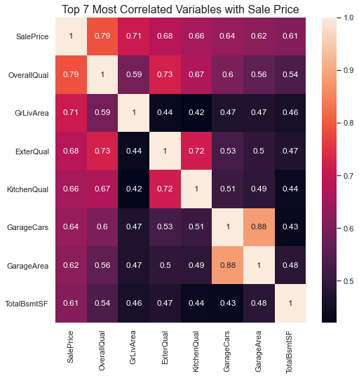

```python
# plot the correlation matrix
vars_to_use = ['SalePrice', 'OverallQual', 'GrLivArea', 'ExterQual', 'KitchenQual',
               'GarageCars', 'GarageArea', 'TotalBsmtSF'] # pick vars
cmap = sns.set(style="darkgrid") # one of the many styles to plot using

f, ax = plt.subplots(figsize=(8, 8))
plt.title('Top 7 Most Correlated Variables with Sale Price', fontsize = 16)
sns.heatmap(df_imputed[vars_to_use].corr(), cmap=cmap, annot=True)
```

### Plot 1

Here, we highlight some of the features that are specifically of interest to us in this work.

**OverallQual** rates the overall quality of the house. Building quality has a significant impact on house price; an improvement in quality from low to medium quality and from medium to high quality leads to home price increases by about 25% [5]. Our dataset ranks the quality of houses based on 10 categories, ranging from "Very Poor" to "Very Excellent."

**GrLivArea** is the above grade (ground) living area square feet. Size is crucial when assessing a home's market value because larger home tend to be of higher value. Homes that have larger living area compared to the typical sized homes in the neighborhood could be in greater demand and sold faster.

**ExterQual** evaluates the quality of the material on the exterior of the home. The exterior of a house can attract more buyers and increase the sale price. This feature has five categories from "poor" to "excellent."

**KitchenQual** is kitchen quality, another important feature to the sale price of a home. More than half of all homebuyers claim that the kitchen's quality was a major factor in their decision to purchase a particular home [6]. Kitchen quality is categorized into five categories from "poor" to "excellent."

**GarageCars** indicates the size of garage in car capacity. The presence of a garage is expected to increase the value of a home.

**GarageArea** is the size of the garage in square feet. A larger garage should raise the selling value of a house and attract more buyers.

**TotalBsmtSF** is the total square feet of the basement area. A basement can remarkably increase the amount of usable living space in the home, and finishing this area can substantially increase the property's value.

The correlation plot above is reflective of the most correlated variables with sale price in the final imputed training set. It just so happens that all the most correlated variables are positively correlated with the outcome of interest. The plot is organized from most to least respectively correlated variables, but all variables show the same general pattern of increase as sale prices go up.

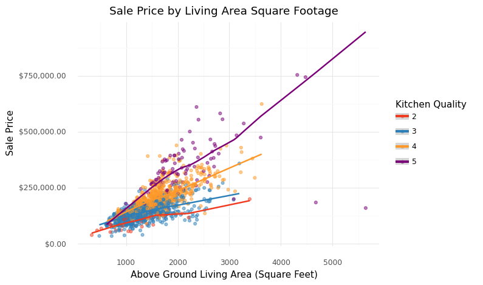

```python
ggplot(df_imputed, aes('GrLivArea', 'SalePrice', color = 'factor(KitchenQual)')) + geom_point(alpha = 0.5) + gg.stat_smooth() + gg.xlab('Above Ground Living Area (Square Feet)') + gg.ylab('Sale Price') + gg.scale_y_continuous(labels = mizani.formatters.currency_format(big_mark = ',')) + gg.ggtitle('Sale Price by Living Area Square Footage') + gg.labs(color = 'Kitchen Quality') + gg.scale_color_manual(('#f03b20', '#2c7fb8', '#fe9929', '#7a0177')) + gg.theme_minimal()
```

### Plot 2

This plot shows us the relationship between sale price, above ground living area square footage, and kitchen quality. From the underlying scatterplot, it is evident that as the square footage of living space increases, so does the sale price, which isn't necessarily a surprising relationship. However, it seems that the majority of houses in the dataset fall between 1000 and 2000 square feet of living space, and some observations serve as proof that large square footage does not necessarily mean higher sale price, as the general trend would suggest. Breaking this relationship down further into how each house was ranked on kitchen quality, we can see how the condition of the home's interior determines more about the sale price than how much room (square feet) the house has available for use. The red line and points show houses whose kitchen quality was ranked (2) "Fair." You'll notice that there is a house with close to 3500 square feet of living space, but the low rated kitchen brings the sale price down. The trend goes on that way, with blue representing (3) "Typical/Average" rated kitchens, yellow indicating (4) "Good", and purple being those whose kitchen's were ranked as (5) "Excellent." It is notable to mention that higher quality kitchens naturally added to the home's value, but also that the purple homes are not necessarily *that* much bigger than the other homes in the dataset, indicating that quality may have more say over quanitity in this case on final sale price.

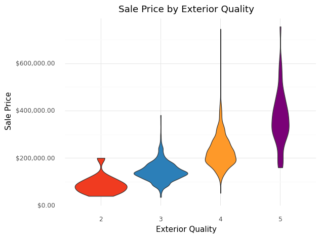

```python
ggplot(df_imputed) + gg.geom_violin(aes('factor(ExterQual)', 'SalePrice', fill = 'factor(ExterQual)'), show_legend = False) + gg.theme_minimal() + gg.xlab('Exterior Quality') + gg.ylab('Sale Price') + gg.ggtitle('Sale Price by Exterior Quality') + gg.scale_y_continuous(labels = mizani.formatters.currency_format(big_mark = ',')) + gg.scale_fill_manual(('#f03b20', '#2c7fb8', '#fe9929', '#7a0177'))
```

### Plot 3

This plot is simpler than the last, but it was important to depict the relationship between exterior quality and sale price as that was found to be the thrid most correlated variable with the outcome in the dataset. From this we gather that there is not a lot of variation in sale price for homes whose exterior quality was ranked (2) "Fair," with none selling for above \$ 200,000. There is a bit more variation in sale price for homes with (3) "Average/Typical" exterior quality, but still these homes tend to sell for under \\$ 200,000. Once a home reaches (4) "Good" exterior quality, we begin to see average sale prices get a bit above the artifical \$ 200,000 threshold affecting average (exterior) quality homes. The most variability in sale prices is seen at the highest ranking of exterior quality, 5) "Excellent." It is, again, obvious that exterior quality plays a role in adding to the sale price because it's what people see - it's a first impression - but, given the spread of sale prices in this category, it seems worthwhile to take a closer look at whether houses that appeared of high quality on the outside had the interior quality necessary to bolster sale prices. Below we take a look at the same plot, split out by the kitchen quality variable introduced in the previous plot.

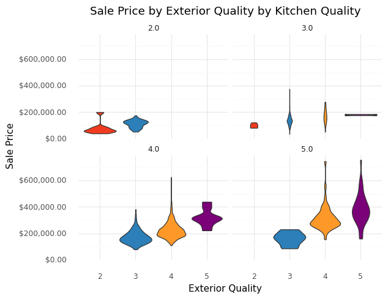

```python
ggplot(df_imputed) + gg.geom_violin(aes('factor(ExterQual)', 'SalePrice', fill = 'factor(ExterQual)'), show_legend = False) + gg.theme_minimal() + gg.xlab('Exterior Quality') + gg.ylab('Sale Price') + gg.ggtitle('Sale Price by Exterior Quality by Kitchen Quality') + gg.scale_y_continuous(labels = mizani.formatters.currency_format(big_mark = ',')) + gg.scale_fill_manual(('#f03b20', '#2c7fb8', '#fe9929', '#7a0177')) + facet_wrap('~KitchenQual')
```

### Plot(s) 4

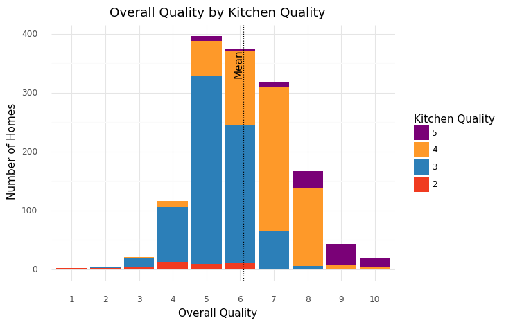

```python
# print(df_imputed.OverallQual.mean())
# print(df_imputed.OverallQual.std())
ggplot(df_imputed) + gg.geom_bar(aes(x = 'factor(OverallQual)', fill = pd.Categorical(df_imputed['KitchenQual']).set_categories(list(reversed(pd.Categorical(df_imputed['KitchenQual']).categories))))) + gg.scale_fill_manual(('#7a0177', '#fe9929', '#2c7fb8', '#f03b20'), name = "Kitchen Quality") + gg.theme_minimal() + gg.xlab('Overall Quality') + gg.ylab('Number of Homes') + gg.ggtitle('Overall Quality by Kitchen Quality') + gg.geom_vline(xintercept = df_imputed.OverallQual.mean(), linetype = 'dotted') + gg.annotate('text', x = df_imputed.OverallQual.mean(), y = 350, label = 'Mean', angle = 90, nudge_x = -0.15)
```

### Plot 5

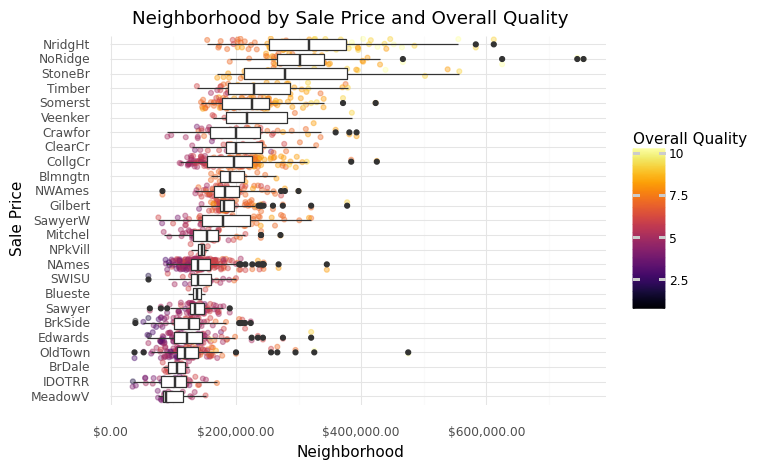

```python
#df_imputed.groupby(['Neighborhood'])['SalePrice'].median().sort_values()
ggplot(df_imputed) + geom_point(aes('reorder(Neighborhood, SalePrice)', 'SalePrice', color = 'OverallQual'),alpha = 0.4, position = "jitter") + gg.geom_boxplot(aes('reorder(Neighborhood, SalePrice)', 'SalePrice')) + gg.coord_flip() + gg.theme_minimal() + gg.xlab('Sale Price') + gg.ylab('Neighborhood') + gg.ggtitle('Neighborhood by Sale Price and Overall Quality') + gg.scale_y_continuous(labels = mizani.formatters.currency_format(big_mark = ',')) + gg.labs(color = "Overall Quality") + gg.scale_color_cmap(cmap_name = 'inferno')
```

### Plot 6

Lastly, there were 25 neighborhoods described by this dataset. As with any city, Ames, Iowa, has some neighborhoods that are more affluent than others, which is depicted above. While there tends to be more variation in sale prices of homes at the top of the list vs. the bottom, the lowest priced home in the most affluent neighborhood, Northridge Heights, is still more expensive than the majority of the homes in the bottom three neighborhoods. Furthermore, the relationship between overall quality of the homes and the sale prices becomes better explained by neighborhoods. Some neighborhoods are more likely to have higher quality homes, which are not necessarily commonplace across all of Ames, Iowa - again, low supply and high demand drives sale prices to increase in these neighborhoods in all likelihood, leading to an increase in variability seen among the sale prices. The plot shows that while the overall quality of a home is heavily indicative of price, the same can be said of home location in all reality. It is also interesting to note that some homes that were relatively expensive in their respective neighborhoods had extremely low overall quality rankings, which seems that it must be some sort of reporting error in the data that should be addressed if further predictive analytics are performed on this dataset.

### 3 Interesting Questions

1. Quality or quantity - which is more determinant of sale price?

**Plots 1** and **2** can be capitalized to answer this question. Of the top 5 most correlated variables with sale price, 3 are qualitative rank-based variables that heavily influence the estimated monetary value of a property. The breakdown and evaluation of **Plot 2** paints a clearer picture of the way that quality seems to be of greater worth than quantity. In simpler terms, a big house is not necessarily a nice house in Ames, Iowa, and a smaller home with higher quality features tends to go for more than a more sizable home of average grade.

1. Do homes typically align interior and exterior quality or are sale prices geared toward one over the other?

1. The overall quality of the home was found to be most correlated with sale price - how does it relate to other variables in the data and shed light on the bigger picture?

The overall quality variable encapsulates and summarizes a multitude of qualitative variables in the dataset. **Plot 5** shows its relationship with kitchen quality. It conveys the direct correlation between the two that is depicted in Plot 1 - how average quality homes tend to have average quality kitchens, and the further above average the overall quality of a home is, the more likely it is to have a highly regarded kitchen. **Plot 6** breaks down the relationship between overall quality and sale price by neighborhood, which is arguably the most important factor in the dataset. This plot proves that certain neighborhoods tend to have higher quality homes than others, which is helpful to know when taking on the task of accurately predicting sale prices. In a way, this graph accentuates the neighborhoods that are relevant to our target market and the overall quality we should expect of houses that fall within the price range of the home buyers we seek to serve.

## Exceptional Work

#### UMAP Explanation

UMAP is a technique to reduce a high dimensional (high-d) dataset to low dimensional (low-d) and plot into a low-d graph to visualize the clusters and relationship between each point. In short, UMAP puts high-d points into a low-d graph, then adjusts the position of each point on the low-d graph until it has the same relationship in high-d.

UMAP takes two parameters, the number of nearest neighbors and minimum distance. It uses the number of nearest neighbors to plug in log2( # of nearest neighbor ), which determines the shape of the similarity score's curve. Similarity score is used to identify points that have a relationship with each other by its relative distance to each point, so when plotting a low-d graph, the clustering will still be the same in high-d. Then, use the minimum distance parameter in the low-d graph to space each point.

Then, UMAP uses Spectral Embedding to place each high-d point into a low-d graph, and adjust the distance between each point based on the low-d similarity scores derived from a t-distribution curve. If two points are close in high-d then UMAP wants to maximize the low-d similarity score, and vice versa for points that are far away.

#### UMAP Implementation + Results

```python
# UMAP dimensionality reduction
import matplotlib.pyplot as plt
from sklearn.preprocessing import StandardScaler
```

```python
#pip uninstall umap
#!pip install umap-learn
```

We want to implement the UMAP for dimension reduction on our whole dataset (59 numeric/ordinal features) instead of selecting a subset of features. This way, we can reduce the dimensionality while retaining as much of the data's structure as possible. We want to view the data, understand its structure, and gain some insight on the data using UMAP.

```python
import umap.umap_ as umap
```

```python
reducer = umap.UMAP()
```

```python
df_numerics_only = df_imputed.select_dtypes(include=np.number)
df_numerics_only.to_csv('df_numerics_only.csv')
df_numerics_only = df_numerics_only.reset_index()
df_numerics_only. shape[1]
```

```
59
```

Now we use the fit_transform for our 59 numeric columns. It calls fit and then transforms data and returns it as a numpy array. Also, since the measurements are made using completely different scales, it we transform each feature into z-scores for a fair comparison.

```python
df_numerics_only1 = df_numerics_only.drop('SalePrice', axis=1)
df_numerics_only1 =df_numerics_only1.values
scaled_data = StandardScaler().fit_transform(df_numerics_only1)
embedding = umap.UMAP(n_neighbors=10).fit_transform(scaled_data)
embedding.shape
```

```
(1458, 2)
```

As a result, there are only two feature columns in an array of 1458 samples (instead of 59). This is due to UMAP's default reduction to 2D. A 2-dimensional representation of the price sale appears in each row of the array.

Since we are working with a large range of prices, converting the sale prices to categories is helpful in analyzing UMAP.

```python
ranges = [0,150000,200000,300000,400000,2000000]
df_numerics_only.SalePrice.groupby(pd.cut(df_numerics_only.SalePrice, ranges)).count()
```

```
SalePrice
(0, 150000]          619
(150000, 200000]     413
(200000, 300000]     311
(300000, 400000]      87
(400000, 2000000]     28
Name: SalePrice, dtype: int64
```

```python
category=pd.cut(df_numerics_only.SalePrice,bins=[0,150000,200000,250000,400000,2000000],labels=['P1','P2','P3','P4','P5'])
df_numerics_only.insert(59,'PriceLevel',category)
```

The resulting embedding can be plotted with the colored data points according to the class to which the prices belong.

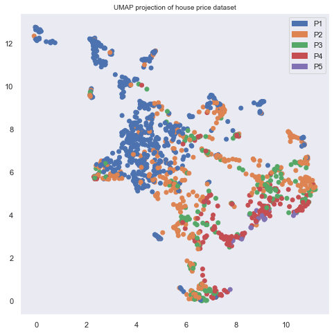

```python
import matplotlib.patches as mpatches

classes=['P1','P2','P3','P4','P5']
fig, ax = plt.subplots(1, figsize=(8, 8))
plt.scatter(
    embedding[:, 0],
    embedding[:, 1],
    c=[sns.color_palette()[x] for x in df_numerics_only.PriceLevel.map({"P1":0, "P2":1, "P3":2,"P4":3,"P5":4,"P6":5})])

#plt.gca().set_aspect('equal', 'datalim')
plt.title('UMAP projection of house price dataset', fontsize=10)

le1 = mpatches.Patch(color=(0.2980392156862745, 0.4470588235294118, 0.6901960784313725)
, label='P1')
le2 = mpatches.Patch(color=(0.8666666666666667, 0.5176470588235295, 0.3215686274509804)
, label='P2')
le3 = mpatches.Patch(color=(0.3333333333333333, 0.6588235294117647, 0.40784313725490196)
, label='P3')
le4 = mpatches.Patch(color=(0.7686274509803922, 0.3058823529411765, 0.3215686274509804)
, label='P4')
le5 = mpatches.Patch(color=(0.5058823529411764, 0.4470588235294118, 0.7019607843137254)
, label='P5')

plt.legend(handles=[le1, le2, le3, le4, le5])
plt.grid()
plt.show()
```

The house price dataset is represented in two dimensions by UMAP above. We see that UMAP is successful in capturing our data's structure. We expect the price levels to fall into clusters corresponding to successive price levels being close to each other. The price classes appear in increasing order from the figure's upper left to the bottom right. By decreasing vertical-coordinate and increasing the horizontal-coordinate, we have a higher sale price in our dataset.

Some clusters overlap with others, and a small mixture of subclusters is at the bottom right. This can be because we have introduced our class price ranges. We only introduced these classes for better visualizations. The prices at the bound of successive classes are close to each other, and that's why we see these overlaps. In addition, we have considered 59 columns of the data out of 81, and these 59 columns cannot fully explain the data structure. Also, even with all features in the data, we will not be able to estimate the price precisely, hence the margin of error outlined in our **Business Understanding**.

## Concluding Remarks

The exercises of Lab 01 have challenged us to look at the Housing data from a unique point of view, and we have gained valuable insight regarding the data story that lies within. It seems there is no "catch-all" variable that explains the great amount of variation among sale prices in Ames, Iowa. We are reminded that the goal of this data collection was to highlight the complexity of factors that go into predicting sale prices.

Moving forward, we would likely apply some sort of penalized linear regression methods or machine learning algorithms (given that we have enough data to calibrate a model) to assist us in finding the best method for predicting sale prices in the Ames housing market, particularly for our target population who affords the median home value around \$ 200, 000.

## Sources

[1] https://www.kaggle.com/c/house-prices-advanced-regression-techniques/

[2] https://www.census.gov/quickfacts/fact/table/amescityiowa/INC110220

[3] https://www.in2013dollars.com/Housing/price-inflation

[4] https://www.kaggle.com/code/erikbruin/house-prices-lasso-xgboost-and-a-detailed-eda/report

[5] https://www.tandfonline.com/doi/abs/10.1080/08882746.2019.1601928?journalCode=rhas20#:~:text=First%2C%20the%20building%20quality%20variable,and%201.3b%2C%20respectively

[6] https://www.cabinetcity.net/2022/03/24/how-much-does-a-kitchen-remodel-increase-home-value/

[7] https://github.com/lmcinnes/umap

[8] https://pair-code.github.io/understanding-umap/